# 5장. 상관분석

### 1절. 상관분석의 개념

#### 1. 상관분석

: 두 변수 간 관계의 정도를 알아보기 위한 분석방법

$$r = \frac{cov(x,y)}{S_x *
S_y}=\frac{\sum^n_{i=1}[(x-\bar x)(y-\bar y)]}{n(S_x*S_y)}$$
상관계수 값이 클수록 데이터 간의 관계가 존재한다.

#### 2. 공분산과 상관계수

- 공분산 : 두 확률변수가 함께 변화하는지의 정도를 측정

#### 3. 상관계수의 해석

| 상관계수 범위 | 해석 |
| --- | --- |
| $\|0.7\| < \rho \le\|1\|$ | 강한 상관이 있다. |
| $\|0.3\| < \rho \le\|0.7\|$ | 약한 상관이 있다. |
| $0<\rho\le\|0.3\|$ | 거의 상관이 없다. |
| $\rho=0$ | 상관관계가 존재하지 않는다. |

### 2절. 상관분석의 유형

#### 1. 피어슨 상관계수

: 두 **연속형** 자료가 모두 **정규성**을 따른다는 가정 하에 선형적 상관관계를 측정, -1~1 값

#### 2. 스피어만 상관계수

: 두 변수가 **정규성을 만족하지 않는** 경우 or 변수가 **순위 및 순서** 형태인 경우 상관관계 사용, -1~1 값

비선형 관계의 연관성도 파악 가능

#### 3. 켄달의 순위상관계수

: 데이터가 $(X_i,Y_i) $ 와 같이 순서쌍으로 주어졌을 경우, -1~1값

- 부합 : $X_i$ 가 커짐에 따라 $Y_i$ 도 커질 경우
- 비부합 : $X_i$ 가 커짐에 따라 $Y_i$ 도 작아질 경우

=> 1 일 경우, 부합쌍의 비율이 100% / -1 일 경우, 비부합쌍의 비율이 100%

### 3절. 상관계수 검정

#### 1. 상관계수에 대한 검정

$H_0$ : 두 변수 간에는 상관관계가 없다. (상관계수=0)

#### 2. R을 이용한 상관분석

- 상관계수 - cor(x,y, method=c(‘pearson’,‘kendall’,‘spearman’), use)
  - use : na값 처리 방법
    - everything : 결측값 존재 시 NA
    - all.obs : 결측값 존재시 오류 메시지
    - complete.obs : 변수별로 결측값을 제외하고 상관계수 계산
    - pairwise.complete.obs : 모든 변수 쌍에서 결측값이 없는 데이터들에 대해 상관계수 계산

```r
data("airquality")
str(airquality)
```

```
## 'data.frame':    153 obs. of  6 variables:
##  $ Ozone  : int  41 36 12 18 NA 28 23 19 8 NA ...
##  $ Solar.R: int  190 118 149 313 NA NA 299 99 19 194 ...
##  $ Wind   : num  7.4 8 12.6 11.5 14.3 14.9 8.6 13.8 20.1 8.6 ...
##  $ Temp   : int  67 72 74 62 56 66 65 59 61 69 ...
##  $ Month  : int  5 5 5 5 5 5 5 5 5 5 ...
##  $ Day    : int  1 2 3 4 5 6 7 8 9 10 ...
```

```r
air <- airquality[,c(1:4)]
str(air)
```

```
## 'data.frame':    153 obs. of  4 variables:
##  $ Ozone  : int  41 36 12 18 NA 28 23 19 8 NA ...
##  $ Solar.R: int  190 118 149 313 NA NA 299 99 19 194 ...
##  $ Wind   : num  7.4 8 12.6 11.5 14.3 14.9 8.6 13.8 20.1 8.6 ...
##  $ Temp   : int  67 72 74 62 56 66 65 59 61 69 ...
```

```r
# 피어슨 상관계수
cor(air, use = 'pairwise.complete.obs', method = 'pearson')
```

```
##              Ozone     Solar.R        Wind       Temp
## Ozone    1.0000000  0.34834169 -0.60154653  0.6983603
## Solar.R  0.3483417  1.00000000 -0.05679167  0.2758403
## Wind    -0.6015465 -0.05679167  1.00000000 -0.4579879
## Temp     0.6983603  0.27584027 -0.45798788  1.0000000
```

```r
# 켄달 상관계수
cor(air, use = 'pairwise.complete.obs', method = 'kendall')
```

```
##              Ozone      Solar.R          Wind       Temp
## Ozone    1.0000000 0.2403194214 -0.4283602915  0.5862988
## Solar.R  0.2403194 1.0000000000  0.0006785596  0.1442337
## Wind    -0.4283603 0.0006785596  1.0000000000 -0.3222418
## Temp     0.5862988 0.1442336719 -0.3222417514  1.0000000
```

```r
# 스피어만 상관계수
cor(air, use = 'pairwise.complete.obs', method = 'spearman')
```

```
##              Ozone       Solar.R          Wind       Temp
## Ozone    1.0000000  0.3481864700 -0.5901551241  0.7740430
## Solar.R  0.3481865  1.0000000000 -0.0009773325  0.2074275
## Wind    -0.5901551 -0.0009773325  1.0000000000 -0.4465408
## Temp     0.7740430  0.2074275160 -0.4465407773  1.0000000
```

- 상관계수에 대한 가설 검정 - cor.test()

```r
cor.test(air$Ozone, air$Wind, method = 'pearson')
```

```
##
##  Pearson's product-moment correlation
##
## data:  air$Ozone and air$Wind
## t = -8.0401, df = 114, p-value = 9.272e-13
## alternative hypothesis: true correlation is not equal to 0
## 95 percent confidence interval:
##  -0.7063918 -0.4708713
## sample estimates:
##        cor
## -0.6015465
```

=> p-value < 0.05이므로 귀무가설을 기각한다. 따라서 두 변수 사이에 상관관계가 존재한다

- 상관계수 행렬을 시각화 - pairs(),corrplot()

```r
air_cor <- cor(air, use = 'pairwise.complete.obs')
air_cor
```

```
##              Ozone     Solar.R        Wind       Temp
## Ozone    1.0000000  0.34834169 -0.60154653  0.6983603
## Solar.R  0.3483417  1.00000000 -0.05679167  0.2758403
## Wind    -0.6015465 -0.05679167  1.00000000 -0.4579879
## Temp     0.6983603  0.27584027 -0.45798788  1.0000000
```

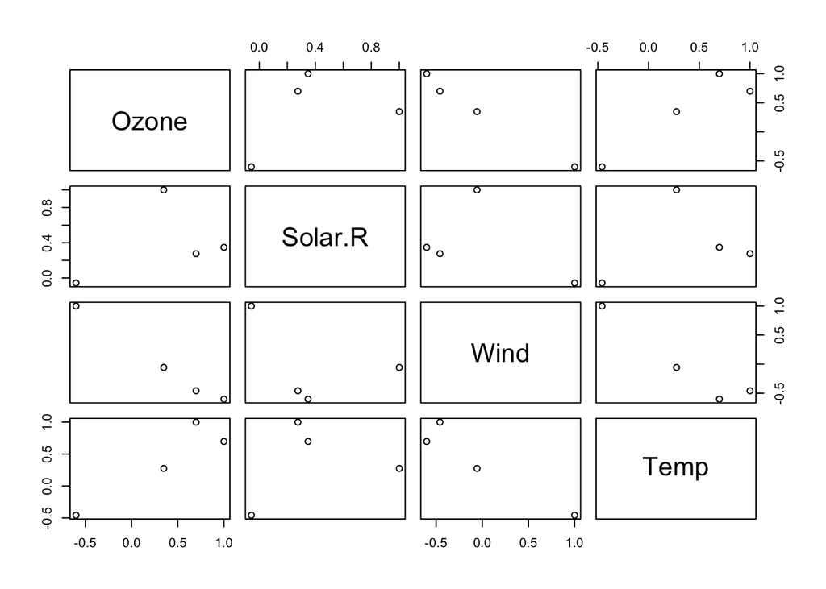

```r
pairs(air_cor)
```